# ps_8.Rmd

Hamaad Mehal

4/13/2020

# 1A

Data summary

| Name | joined_polls |
| --- | --- |
| Number of rows | 4929 |
| Number of columns | 21 |
| _______________________ |  |
| Column type frequency: |  |
| numeric | 2 |
| ________________________ |  |
| Group variables | None |

**Variable type: numeric**

| skim_variable | n_missing | complete_rate | mean | sd | p0 | p25 | p50 | p75 | p100 | hist |
| --- | --- | --- | --- | --- | --- | --- | --- | --- | --- | --- |
| total_tweets | 0 | 1 | 19.73 | 28.41 | 0.0 | 0.0 | 0 | 41 | 109 | ▇▁▂▁▁ |
| approve | 0 | 1 | 41.36 | 4.08 | 23.9 | 38.1 | 41 | 44 | 59 | ▁▂▇▃▁ |

# 1B

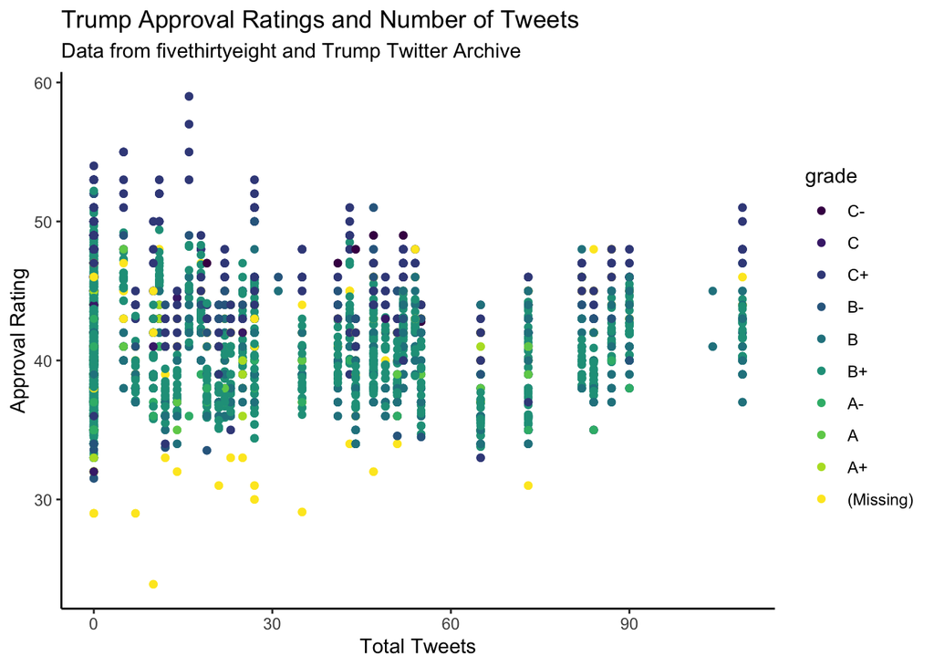

The correlation coefficient between the approval rating and the number of tweets is -0.0261923.

# 2A

Effect of Number of Tweets and Poll Quality on Reported Approval Rating

| Data from fivethirtyeight and Trump Tweet Archive Variable | Data from fivethirtyeight and Trump Tweet Archive Estimate | Data from fivethirtyeight and Trump Tweet Archive Lower Bound | Data from fivethirtyeight and Trump Tweet Archive Upper Bound |
| --- | --- | --- | --- |
| (Intercept) | 41.492382414 | 41.353192807 | 41.6315720214 |
| total_tweets | -0.003923101 | -0.007912576 | 0.0000663732 |
| high_q | -2.540079792 | -3.300630080 | -1.7795295042 |

# 2B

The average treatment effect of high_q is that for high-quality polls, there is a 2.540 unit decrease in reported approval rating compared to all polls on all tweets. Trump’s approval rating is predicted to be 2.3540 units lower than that of all tweets (-0.004) when compared to its impact on high-quality polls. 95% of the time, the true value is in between the bounds according to the frequentist interprtation. According to the Bayesian interpretation, we can be 95% sure that the true value will lie between the upper and lower bounds.

# 2C

Effect of More Tweets on High Quality Polls

| Data from fivethirtyeight and Trump Tweet Archive Variable | Data from fivethirtyeight and Trump Tweet Archive Estimate | Data from fivethirtyeight and Trump Tweet Archive Lower Bound | Data from fivethirtyeight and Trump Tweet Archive Upper Bound |
| --- | --- | --- | --- |
| (Intercept) | 41.500711791 | 41.361032985 | 41.6403905964 |
| total_tweets | -0.004344031 | -0.008377698 | -0.0003103643 |
| high_q | -2.874972881 | -3.771974344 | -1.9779714175 |
| total_tweets:high_q | 0.019158192 | -0.008054559 | 0.0463709427 |

# 2D

```
## [1] 39.87013
```

```
## numeric(0)
```

# 2E

I would interpret the coefficient with total tweets in this regression as the impact the total tweets have on his approval rating and the estimated causal effect it has on Democrats’ approval ratings. The actual coefficient would be the estimated effect that one more tweet per week would have on the Democrats’ approval rating. This would also be the effect that the tweets have on his reported approval ratings. I would interpret the coefficient of approval as the causal effect that the reported approval ratings have on Democrats’ approval ratings. In this case, the coefficient is the impact that one more increase in the rating has on the Democrats’ approval rating. Lastly, the coefficient regression for Democrats is the causal effect being assigned to the high or low tweet volume has on Democrats’ approval ratings. This is the average causal effect that a high or low tweet volume has on the approval rates on Democrats as it is randomly assigned and looks directly at the changes in approval rating associated with Trump’s week’s assigned treatment (high or low tweet volume).

# 3

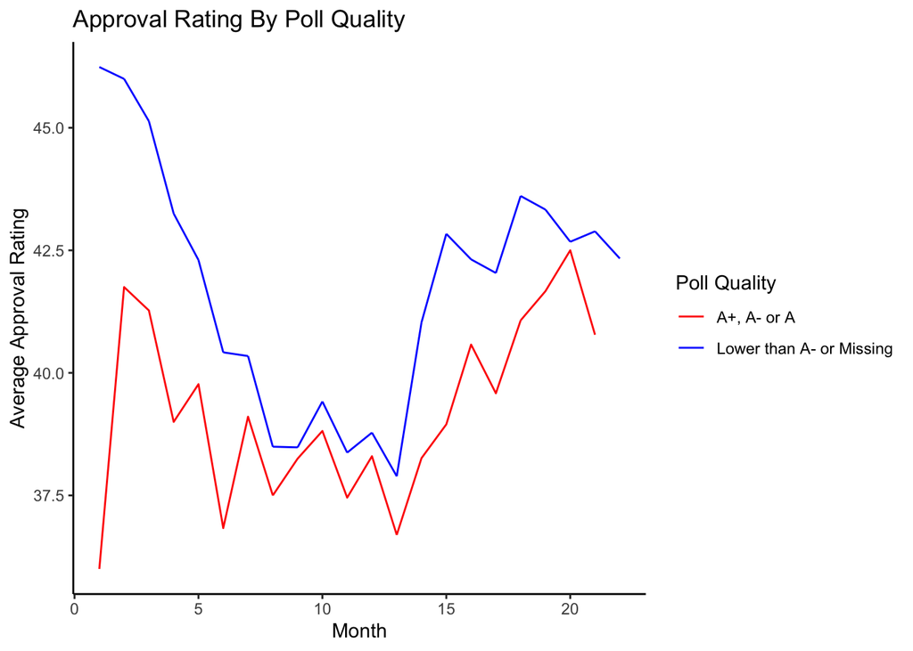

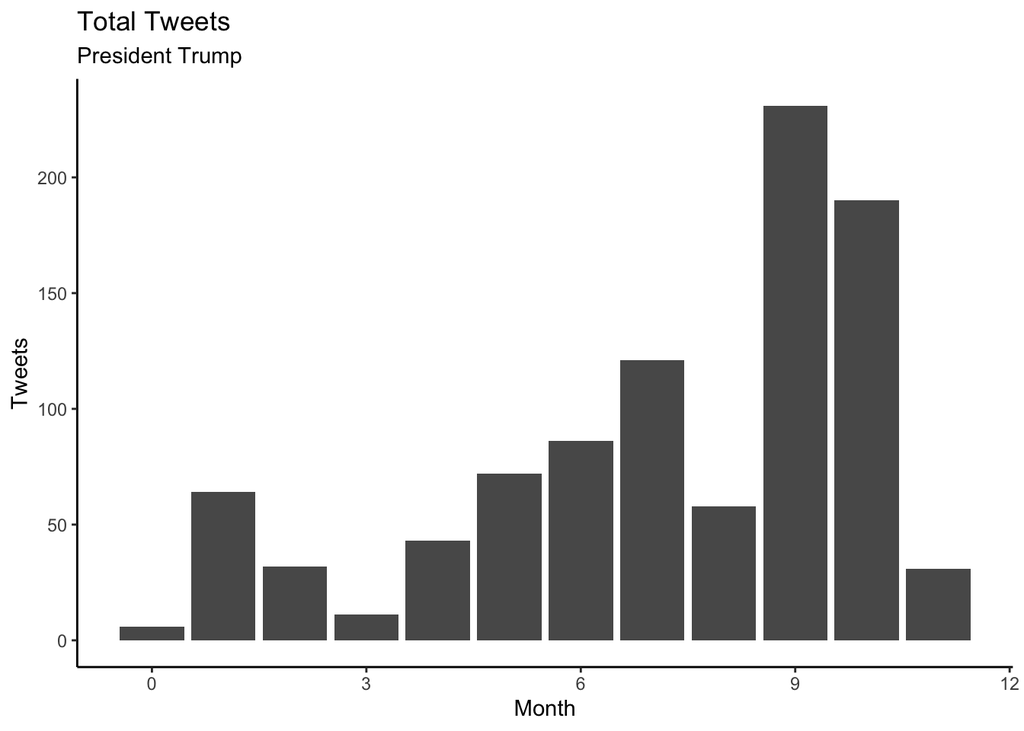

Collaborators: Tahmid Ahmed, Jun Yong Kim, Naina Tejani, Hamid Khan